# Are Harris County Drivers the Worst in Texas?

Fredy Guevara

2026-03-12

# Introduction

This project studies whether Harris County, which includes Houston, has the worst drivers among a selected group of Texas counties. The counties included in this analysis are Harris, Travis, Bexar, Montgomery, Hays, Medina, Hidalgo, Hale, and Lipscomb.

The goal is not just to compare the total number of crashes, since larger counties naturally tend to have more crashes. Instead, this project compares counties using crash rates, fatal crash rates, and the proportions of crashes involving speeding, alcohol, and distracted driving.

# Research Question

Does the data suggest that Harris County has the worst drivers among the selected Texas counties?

# Data

The data used in this project were obtained from the Texas Department of Transportation (TxDOT) Motor Vehicle Crash Statistics database:

https://www.txdot.gov/data-maps/crash-reports-records/motor-vehicle-crash-statistics.html

The dataset was constructed by extracting county-level crash statistics for the year 2024 from several PDF reports provided on the TxDOT website. These reports included:

- Total crashes and injuries by county
- Speed-related crashes
- DUI (alcohol-related) crashes
- Distracted driving crashes
- Fatal crashes

The counties selected for this analysis are Harris, Travis, Bexar, Montgomery, Hays, Medina, Hidalgo, Hale, and Lipscomb.

Population estimates for each county were taken for July 2024 in order to match the time frame of the crash data.

The raw data were first organized in Excel and then imported into R for cleaning, transformation, and analysis.

```r
crash <- read.csv("Crash_Data_2024.csv")

head(crash)
```

```
##       County Total_Crashes Fatal_Crashes Speed_Crashes DUI_Crashes
## 1     Harris       115,173           546        37,316       3,357
## 2     Travis        15,872           139         3,047       1,182
## 3      Bexar        48,522           205         7,516       1,654
## 4 Montgomery        12,352            59         4,576      485.00
## 5       Hays         3,602            26         1,122      240.00
## 6     Medina        836.00            11        196.00       46.00
##   Distracted_Crashes Serious_Crashes Minor_Crashes Population
## 1              9,851          28,282        10,608  5,003,892
## 2              5,134          511.00         3,391  1,395,906
## 3             17,761          773.00         7,023  2,167,567
## 4              1,802          300.00         1,617    775,723
## 5             910.00          138.00        707.00    294,840
## 6             191.00           32.00        140.00     56,647
```

```r
str(crash)
```

```
## 'data.frame':    9 obs. of  9 variables:
##  $ County            : chr  "Harris" "Travis" "Bexar" "Montgomery" ...
##  $ Total_Crashes     : chr  "115,173" "15,872" "48,522" "12,352" ...
##  $ Fatal_Crashes     : num  546 139 205 59 26 11 57 4 1
##  $ Speed_Crashes     : chr  "37,316" "3,047" "7,516" "4,576" ...
##  $ DUI_Crashes       : chr  "3,357" "1,182" "1,654" "485.00" ...
##  $ Distracted_Crashes: chr  "9,851" "5,134" "17,761" "1,802" ...
##  $ Serious_Crashes   : chr  "28,282" "511.00" "773.00" "300.00" ...
##  $ Minor_Crashes     : chr  "10,608" "3,391" "7,023" "1,617" ...
##  $ Population        : chr  "5,003,892" "1,395,906" "2,167,567" "775,723" ...
```

# Creating New Variables

To compare counties fairly, several derived variables were created using the following formulas.
$$\text{Crash Rate} = \frac{\text{Total Crashes}}{\text{Population}}
\times 100{,}000$$

$$\text{Fatal Crash Rate} = \frac{\text{Fatal Crashes}}{\text{Population}}
\times 100{,}000$$

$$\text{Speed Percent} = \frac{\text{Speed Crashes}}{\text{Total Crashes}}$$

$$\text{DUI Percent} = \frac{\text{DUI Crashes}}{\text{Total Crashes}}$$

$$\text{Distracted Percent} = \frac{\text{Distracted Crashes}}{\text{Total
Crashes}}$$

$$\text{Severity Percent} = \frac{\text{Fatal Crashes + Serious
Crashes}}{\text{Total Crashes}}$$

```r
crash <- crash %>%
  mutate(
    Total_Crashes = as.numeric(gsub(",", "", Total_Crashes)),
    Population = as.numeric(gsub(",", "", Population)),
    Fatal_Crashes = as.numeric(gsub(",", "", Fatal_Crashes)),
    Speed_Crashes = as.numeric(gsub(",", "", Speed_Crashes)),
    DUI_Crashes = as.numeric(gsub(",", "", DUI_Crashes)),
    Distracted_Crashes = as.numeric(gsub(",", "", Distracted_Crashes)),
    Serious_Crashes = as.numeric(gsub(",", "", Serious_Crashes)),
    Minor_Crashes = as.numeric(gsub(",", "", Minor_Crashes))
  )

crash <- crash %>%
  mutate(
    Crash_Rate = (Total_Crashes / Population) * 100000,
    Fatal_Rate = (Fatal_Crashes / Population) * 100000,
    SpeedPercent = Speed_Crashes / Total_Crashes,
    DUIPercent = DUI_Crashes / Total_Crashes,
    DistractedPercent = Distracted_Crashes / Total_Crashes,
    SeverityPercent = (Fatal_Crashes + Serious_Crashes) / Total_Crashes
  )

summary(crash)
```

```
##     County          Total_Crashes    Fatal_Crashes   Speed_Crashes
##  Length:9           Min.   :    25   Min.   :  1.0   Min.   :    5
##  Class :character   1st Qu.:   836   1st Qu.: 11.0   1st Qu.:  196
##  Mode  :character   Median : 12352   Median : 57.0   Median : 3047
##                     Mean   : 23716   Mean   :116.4   Mean   : 6609
##                     3rd Qu.: 16601   3rd Qu.:139.0   3rd Qu.: 5577
##                     Max.   :115173   Max.   :546.0   Max.   :37316
##   DUI_Crashes     Distracted_Crashes Serious_Crashes Minor_Crashes
##  Min.   :   0.0   Min.   :    2      Min.   :    0   Min.   :    1
##  1st Qu.:  46.0   1st Qu.:  191      1st Qu.:   32   1st Qu.:  140
##  Median : 485.0   Median : 1572      Median :  294   Median : 1617
##  Mean   : 860.1   Mean   : 4148      Mean   : 3372   Mean   : 2832
##  3rd Qu.:1182.0   3rd Qu.: 5134      3rd Qu.:  511   3rd Qu.: 3391
##  Max.   :3357.0   Max.   :17761      Max.   :28282   Max.   :10608
##    Population        Crash_Rate       Fatal_Rate      SpeedPercent
##  Min.   :   2745   Min.   : 910.7   Min.   : 6.140   Min.   :0.1549
##  1st Qu.:  56647   1st Qu.:1221.7   1st Qu.: 8.818   1st Qu.:0.2000
##  Median : 775723   Median :1475.8   Median : 9.958   Median :0.2735
##  Mean   :1184167   Mean   :1567.0   Mean   :13.480   Mean   :0.2663
##  3rd Qu.:1395906   3rd Qu.:1788.2   3rd Qu.:12.578   3rd Qu.:0.3240
##  Max.   :5003892   Max.   :2301.7   Max.   :36.430   Max.   :0.3705
##    DUIPercent      DistractedPercent SeverityPercent
##  Min.   :0.00000   Min.   :0.08000   Min.   :0.02016
##  1st Qu.:0.03409   1st Qu.:0.09469   1st Qu.:0.02906
##  Median :0.04530   Median :0.22847   Median :0.04095
##  Mean   :0.04429   Mean   :0.20145   Mean   :0.06002
##  3rd Qu.:0.05502   3rd Qu.:0.25264   3rd Qu.:0.04553
##  Max.   :0.07447   Max.   :0.36604   Max.   :0.25030
```

# Comparing Counties by Crash Rate

The first comparison ranks counties by crash rate rather than by total crashes.

```r
crash %>%
  arrange(desc(Crash_Rate))
```

```
##       County Total_Crashes Fatal_Crashes Speed_Crashes DUI_Crashes
## 1     Harris        115173           546         37316        3357
## 2      Bexar         48522           205          7516        1654
## 3    Hidalgo         16601            57          5577         752
## 4 Montgomery         12352            59          4576         485
## 5     Medina           836            11           196          46
## 6       Hale           457             4           125          25
## 7       Hays          3602            26          1122         240
## 8     Travis         15872           139          3047        1182
## 9   Lipscomb            25             1             5           0
##   Distracted_Crashes Serious_Crashes Minor_Crashes Population Crash_Rate
## 1               9851           28282         10608    5003892  2301.6684
## 2              17761             773          7023    2167567  2238.5467
## 3               1572             294          1932     928384  1788.1609
## 4               1802             300          1617     775723  1592.3210
## 5                191              32           140      56647  1475.8063
## 6                108              15            68      31802  1437.0165
## 7                910             138           707     294840  1221.6796
## 8               5134             511          3391    1395906  1137.0393
## 9                  2               0             1       2745   910.7468
##   Fatal_Rate SpeedPercent DUIPercent DistractedPercent SeverityPercent
## 1  10.911506    0.3239995 0.02914746        0.08553220      0.25030172
## 2   9.457608    0.1548988 0.03408763        0.36604015      0.02015581
## 3   6.139701    0.3359436 0.04529848        0.09469309      0.02114330
## 4   7.605808    0.3704663 0.03926490        0.14588731      0.02906412
## 5  19.418504    0.2344498 0.05502392        0.22846890      0.05143541
## 6  12.577825    0.2735230 0.05470460        0.23632385      0.04157549
## 7   8.818342    0.3114936 0.06662965        0.25263742      0.04553026
## 8   9.957691    0.1919733 0.07447077        0.32346270      0.04095262
## 9  36.429872    0.2000000 0.00000000        0.08000000      0.04000000
```

## Interpretation

Ranking counties by crash rate provides a more meaningful comparison than total crashes because it adjusts for population differences. Larger counties such as Harris and Bexar naturally have more crashes, but the crash rate shows how frequent crashes are relative to population size.

This comparison focuses on the more severe outcomes.

```r
crash %>%
  arrange(desc(Fatal_Rate))
```

```
##       County Total_Crashes Fatal_Crashes Speed_Crashes DUI_Crashes
## 1   Lipscomb            25             1             5           0
## 2     Medina           836            11           196          46
## 3       Hale           457             4           125          25
## 4     Harris        115173           546         37316        3357
## 5     Travis         15872           139          3047        1182
## 6      Bexar         48522           205          7516        1654
## 7       Hays          3602            26          1122         240
## 8 Montgomery         12352            59          4576         485
## 9    Hidalgo         16601            57          5577         752
##   Distracted_Crashes Serious_Crashes Minor_Crashes Population Crash_Rate
## 1                  2               0             1       2745   910.7468
## 2                191              32           140      56647  1475.8063
## 3                108              15            68      31802  1437.0165
## 4               9851           28282         10608    5003892  2301.6684
## 5               5134             511          3391    1395906  1137.0393
## 6              17761             773          7023    2167567  2238.5467
## 7                910             138           707     294840  1221.6796
## 8               1802             300          1617     775723  1592.3210
## 9               1572             294          1932     928384  1788.1609
##   Fatal_Rate SpeedPercent DUIPercent DistractedPercent SeverityPercent
## 1  36.429872    0.2000000 0.00000000        0.08000000      0.04000000
## 2  19.418504    0.2344498 0.05502392        0.22846890      0.05143541
## 3  12.577825    0.2735230 0.05470460        0.23632385      0.04157549
## 4  10.911506    0.3239995 0.02914746        0.08553220      0.25030172
## 5   9.957691    0.1919733 0.07447077        0.32346270      0.04095262
## 6   9.457608    0.1548988 0.03408763        0.36604015      0.02015581
## 7   8.818342    0.3114936 0.06662965        0.25263742      0.04553026
## 8   7.605808    0.3704663 0.03926490        0.14588731      0.02906412
## 9   6.139701    0.3359436 0.04529848        0.09469309      0.02114330
```

## Interpretation

The fatal crash rate highlights how dangerous crashes are in each county, not just how often they occur. Some counties may have lower total crash rates but higher fatality rates, suggesting more severe driving conditions or higher-risk environments such as rural highways.

# Crash Rate Visualization

The graph below shows crash rates per 100,000 people for the selected counties.

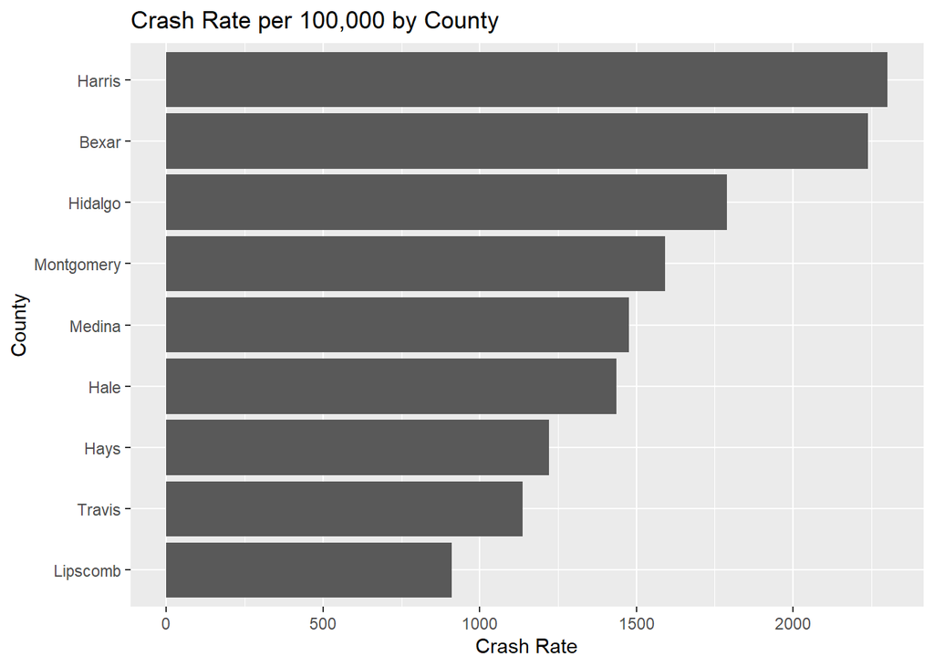

```r
ggplot(crash, aes(x = reorder(County, Crash_Rate), y = Crash_Rate)) +
  geom_col() +
  coord_flip() +
  labs(
    title = "Crash Rate per 100,000 by County",
    x = "County",
    y = "Crash Rate"
  )
```

## Interpretation

This scatterplot checks whether counties with a higher share of speed-related crashes also tend to have higher crash rates.

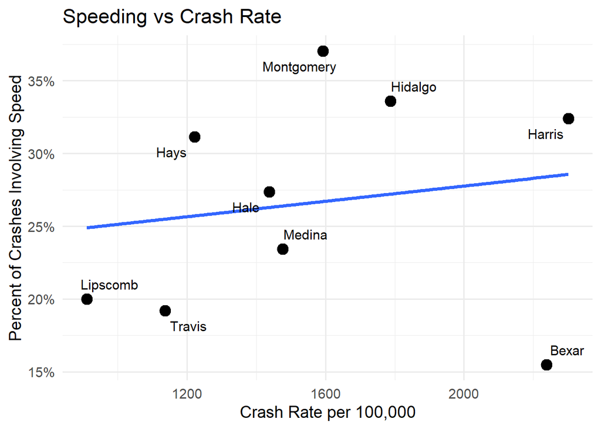

```r
ggplot(crash, aes(x = Crash_Rate, y = SpeedPercent, label = County)) +
  geom_point(size = 4) +
  geom_smooth(method = "lm", se = FALSE) +
  geom_text_repel(
    size = 4,
    box.padding = 0.5,
    point.padding = 0.3
  ) +
  scale_y_continuous(labels = percent_format(accuracy = 1)) +
  labs(
    title = "Speeding vs Crash Rate",
    x = "Crash Rate per 100,000",
    y = "Percent of Crashes Involving Speed"
  ) +
  theme_minimal(base_size = 14)
```

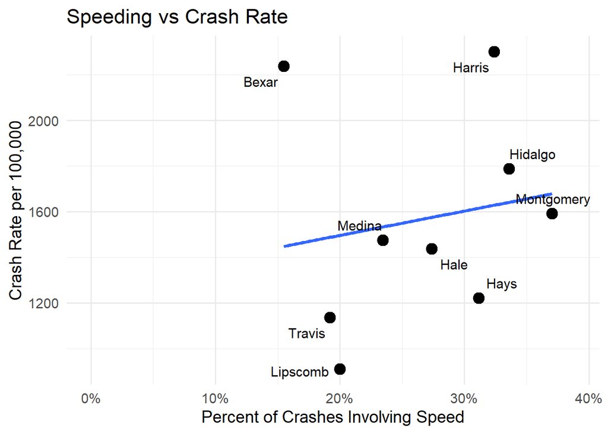

```r
# Fixed so it starts at 0
ggplot(crash, aes(x = SpeedPercent, y = Crash_Rate, label = County)) +
  geom_point(size = 4) +
  geom_smooth(method = "lm", se = FALSE) +
  geom_text_repel(
    size = 4,
    box.padding = 0.5,
    point.padding = 0.3
  ) +
  scale_x_continuous(
    labels = percent_format(accuracy = 1),
    limits = c(0, max(crash$SpeedPercent) * 1.05)  # 👈 THIS FIX
  ) +
  labs(
    title = "Speeding vs Crash Rate",
    x = "Percent of Crashes Involving Speed",
    y = "Crash Rate per 100,000"
  ) +
  theme_minimal(base_size = 14)
```

```r
# will not use since it does not look right starting at 0
```

## Interpretation

# Distracted Driving vs Crash Rate

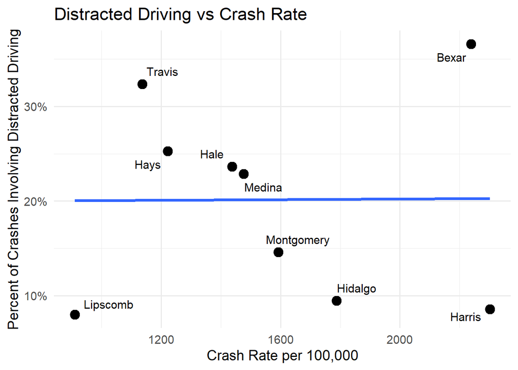

```r
ggplot(crash, aes(x = Crash_Rate, y = DistractedPercent, label = County)) +
  geom_point(size = 4) +
  geom_smooth(method = "lm", se = FALSE, aes(group = 1), linetype = "solid") +
  geom_text_repel(
    size = 4,
    box.padding = 0.5,
    point.padding = 0.3
  ) +
  scale_y_continuous(labels = percent_format(accuracy = 1)) +
  labs(
    title = "Distracted Driving vs Crash Rate",
    x = "Crash Rate per 100,000",
    y = "Percent of Crashes Involving Distracted Driving"
  ) +
  theme_minimal(base_size = 14)
```

# Drinking and Driving

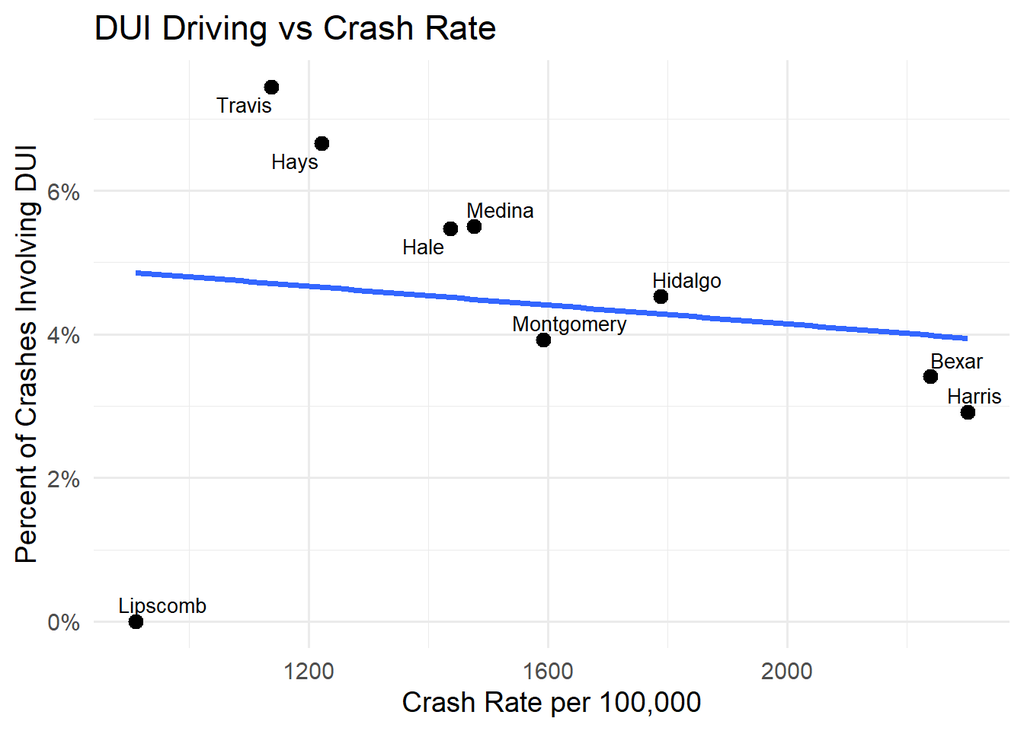

```r
ggplot(crash, aes(x = Crash_Rate, y = DUIPercent, label = County)) +
  geom_point(size = 3) +
  geom_smooth(method = "lm", se = FALSE, aes(group = 1)) +
  geom_text_repel(size = 3.5) +
  scale_y_continuous(labels = percent_format(accuracy = 1)) +
  labs(
    title = "DUI Driving vs Crash Rate",
    x = "Crash Rate per 100,000",
    y = "Percent of Crashes Involving DUI"
  ) +
  theme_minimal(base_size = 14)
```

# Table for the Percentages

```r
crash %>%
  select(County, Crash_Rate, Fatal_Rate, SpeedPercent, DUIPercent, DistractedPercent, SeverityPercent) %>%
  arrange(desc(Crash_Rate))
```

```
##       County Crash_Rate Fatal_Rate SpeedPercent DUIPercent DistractedPercent
## 1     Harris  2301.6684  10.911506    0.3239995 0.02914746        0.08553220
## 2      Bexar  2238.5467   9.457608    0.1548988 0.03408763        0.36604015
## 3    Hidalgo  1788.1609   6.139701    0.3359436 0.04529848        0.09469309
## 4 Montgomery  1592.3210   7.605808    0.3704663 0.03926490        0.14588731
## 5     Medina  1475.8063  19.418504    0.2344498 0.05502392        0.22846890
## 6       Hale  1437.0165  12.577825    0.2735230 0.05470460        0.23632385
## 7       Hays  1221.6796   8.818342    0.3114936 0.06662965        0.25263742
## 8     Travis  1137.0393   9.957691    0.1919733 0.07447077        0.32346270
## 9   Lipscomb   910.7468  36.429872    0.2000000 0.00000000        0.08000000
##   SeverityPercent
## 1      0.25030172
## 2      0.02015581
## 3      0.02114330
## 4      0.02906412
## 5      0.05143541
## 6      0.04157549
## 7      0.04553026
## 8      0.04095262
## 9      0.04000000
```

# Confidence Interval

To estimate the crash rate, a confidence interval is calculated using:

$$\hat{p} = \frac{\text{Total Crashes}}{\text{Population}}$$

$$\hat{p} \pm z \sqrt{\frac{\hat{p}(1-\hat{p})}{n}}$$

# Confidence Interval for Harris County

Here, $\hat{p}$ represents the observed crash proportion and $n$ is the population of Harris County. The value $z = 1.96$ corresponds to a 95% confidence level.

The results below show the estimated range for the crash rate in Harris County. z=1.96.

```r
harris <- crash %>% filter(County == "Harris")

p_hat_harris <- harris$Total_Crashes / harris$Population
n_harris <- harris$Population
z <- 1.96
se_harris <- sqrt((p_hat_harris * (1 - p_hat_harris)) / n_harris)

lower_harris <- p_hat_harris - z * se_harris
upper_harris <- p_hat_harris + z * se_harris

lower_harris * 100000
```

```
## [1] 2288.529
```

```r
upper_harris * 100000
```

```
## [1] 2314.808
```

# Confidence Interval for Montgomery County

The same method was applied to Montgomery County in order to compare the estimated crash rates between counties.

```r
montgomery <- crash %>% filter(County == "Montgomery")

p_hat_montgomery <- montgomery$Total_Crashes / montgomery$Population
n_montgomery <- montgomery$Population
se_montgomery <- sqrt((p_hat_montgomery * (1 - p_hat_montgomery)) / n_montgomery)

lower_montgomery <- p_hat_montgomery - z * se_montgomery
upper_montgomery <- p_hat_montgomery + z * se_montgomery

lower_montgomery * 100000
```

```
## [1] 1564.464
```

```r
upper_montgomery * 100000
```

```
## [1] 1620.178
```

# Confidence Interval Comparison Table

```r
tibble(
  County = c("Harris", "Montgomery"),
  Lower_CI = c(lower_harris, lower_montgomery) * 100000,
  Upper_CI = c(upper_harris, upper_montgomery) * 100000
)
```

```
## # A tibble: 2 × 3
##   County     Lower_CI Upper_CI
##   <chr>         <dbl>    <dbl>
## 1 Harris        2289.    2315.
## 2 Montgomery    1564.    1620.
```

## Interpretation

The confidence intervals provide a range of plausible values for the true crash rate in each county. If the intervals for Harris County and Montgomery County overlap significantly, then the difference between the two counties may not be statistically meaningful. If they do not overlap, this suggests a real difference in crash risk between the counties.

# New Code I made to just include all the counties confidence intervals.

```r
ci_all <- crash %>%
  mutate(
    p_hat = Total_Crashes / Population,
    n = Population,
    z = 1.96,
    se = sqrt((p_hat * (1 - p_hat)) / n),
    Lower_CI = (p_hat - z * se) * 100000,
    Upper_CI = (p_hat + z * se) * 100000,
    Crash_Rate = p_hat * 100000
  ) %>%
  select(County, Crash_Rate, Lower_CI, Upper_CI)

knitr::kable(
  ci_all %>% mutate(across(-County, ~ round(.x, 2))),
  booktabs = TRUE,
  caption = "95% Confidence Intervals for Crash Rates"
)
```

95% Confidence Intervals for Crash Rates

| County | Crash_Rate | Lower_CI | Upper_CI |
| --- | --- | --- | --- |
| Harris | 2301.67 | 2288.53 | 2314.81 |
| Travis | 1137.04 | 1119.45 | 1154.63 |
| Bexar | 2238.55 | 2218.85 | 2258.24 |
| Montgomery | 1592.32 | 1564.46 | 1620.18 |
| Hays | 1221.68 | 1182.03 | 1261.33 |
| Medina | 1475.81 | 1376.51 | 1575.11 |
| Hidalgo | 1788.16 | 1761.20 | 1815.12 |
| Hale | 1437.02 | 1306.21 | 1567.82 |
| Lipscomb | 910.75 | 555.36 | 1266.13 |

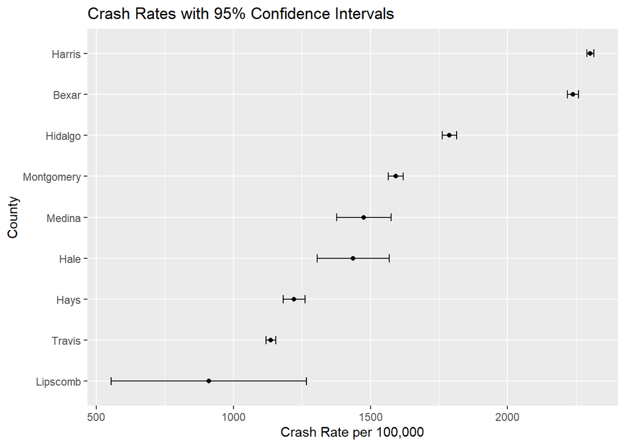

```r
ggplot(ci_all, aes(x = reorder(County, Crash_Rate), y = Crash_Rate)) +
  geom_point() +
  geom_errorbar(aes(ymin = Lower_CI, ymax = Upper_CI), width = 0.2) +
  coord_flip() +
  labs(
    title = "Crash Rates with 95% Confidence Intervals",
    x = "County",
    y = "Crash Rate per 100,000"
  )
```

```r
# replacing population with total crashes to see what happens with the confidence interval.
ci_all <- crash %>%
  mutate(
    p_hat = Total_Crashes / Population,
    n = Total_Crashes,
    z = 1.96,
   se = sqrt((p_hat * (1 - p_hat)) / Total_Crashes),
    Lower_CI = (p_hat - z * se) * 100000,
    Upper_CI = (p_hat + z * se) * 100000,
    Crash_Rate = p_hat * 100000
  ) %>%
  select(County, Crash_Rate, Lower_CI, Upper_CI)

knitr::kable(
  ci_all %>% mutate(across(-County, ~ round(.x, 2))),
  booktabs = TRUE,
  caption = "95% Confidence Intervals for Crash Rates"
)
```

95% Confidence Intervals for Crash Rates

| County | Crash_Rate | Lower_CI | Upper_CI |
| --- | --- | --- | --- |
| Harris | 2301.67 | 2215.06 | 2388.27 |
| Travis | 1137.04 | 972.09 | 1301.99 |
| Bexar | 2238.55 | 2106.92 | 2370.18 |
| Montgomery | 1592.32 | 1371.56 | 1813.08 |
| Hays | 1221.68 | 862.93 | 1580.43 |
| Medina | 1475.81 | 658.40 | 2293.21 |
| Hidalgo | 1788.16 | 1586.57 | 1989.75 |
| Hale | 1437.02 | 345.86 | 2528.17 |
| Lipscomb | 910.75 | -2813.15 | 4634.65 |

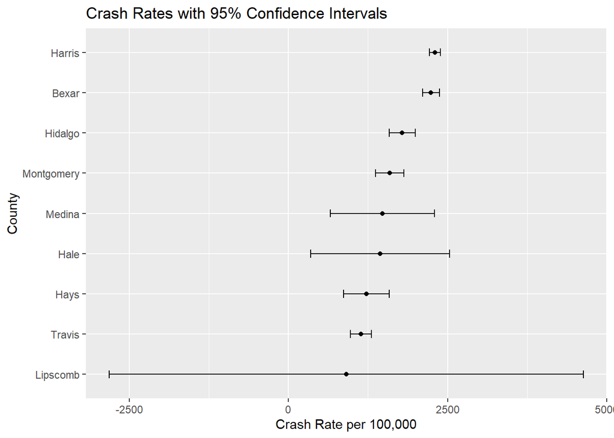

```r
ggplot(ci_all, aes(x = reorder(County, Crash_Rate), y = Crash_Rate)) +
  geom_point() +
  geom_errorbar(aes(ymin = Lower_CI, ymax = Upper_CI), width = 0.2) +
  coord_flip() +
  labs(
    title = "Crash Rates with 95% Confidence Intervals",
    x = "County",
    y = "Crash Rate per 100,000"
  )
```

# Regression Model

A linear regression model was used to see whether crash rate is associated with the proportions of speed-related crashes, DUI crashes, and distracted-driving crashes.

```r
model <- lm(Crash_Rate ~ SpeedPercent + DUIPercent + DistractedPercent, data = crash)

summary(model)
```

```
##
## Call:
## lm(formula = Crash_Rate ~ SpeedPercent + DUIPercent + DistractedPercent,
##     data = crash)
##
## Residuals:
##       1       2       3       4       5       6       7       8       9
##  681.24  -69.29  374.81 -354.24 -424.44  134.12  334.42 -142.80 -533.82
##
## Coefficients:
##                    Estimate Std. Error t value Pr(>|t|)
## (Intercept)           84.01    1372.55   0.061    0.954
## SpeedPercent        5107.92    4239.00   1.205    0.282
## DUIPercent        -16501.03   14148.70  -1.166    0.296
## DistractedPercent   4237.23    3694.46   1.147    0.303
##
## Residual standard error: 519.7 on 5 degrees of freedom
## Multiple R-squared:   0.25,  Adjusted R-squared:   -0.2
## F-statistic: 0.5556 on 3 and 5 DF,  p-value: 0.6667
```

## Interpretation

The regression model examines how crash rates are related to speeding, DUI, and distracted driving.

The coefficients show how much the crash rate is expected to change when each factor increases, holding the others constant. Variables with smaller p-values (typically less than 0.05) are considered statistically significant predictors.

If speeding has the largest coefficient and is statistically significant, this suggests that it is the strongest contributor to higher crash rates among the counties studied. Similarly, significant DUI or distracted driving variables indicate their importance in explaining crash behavior.

The $R^2$ value shows how much of the variation in crash rates is explained by the model. A higher value indicates a better fit.

# Conclusion

This analysis compared selected Texas counties using crash rates, fatal crash rates, confidence intervals, and regression modeling.

Overall, the results show that determining the “worst drivers” is not simply about total crashes, but about relative risk and contributing behaviors.

# Possible Next Steps

There are several ways this project could be expanded:

compare Harris County to all Texas counties instead of only a selected group add more explanatory variables, such as rural versus urban road type analyze fatal crash rate as a second regression response create a slide presentation based on the main tables and graphs